[figure not shown]

# GET00203 - Estatística Computacional 1

Aula 09 - Estimadores de Máxima Verossimilhança

[Rafael Erbisti](https://sites.google.com/site/rerbisti)

### Estimadores de Máxima Verossimilhança

#### Definição

O estimador de máxima verossimilhança (EMV) de $\theta$, quando existe, é o valor $\hat{\theta}_{MV} \in \Theta$, que maximiza a função de verossimilhança $l(\theta; X)$, isto é,

$$\hat{\theta}_{MV} = \underset{\theta \in \Theta}{\arg \max} \ l(\theta;
X);$$

e seu valor observado é a estimativa de máxima verossimilhança.

#### Maximização de uma função

**Como faço para maximizar uma função?**

Suponha que você esteja interessado em maximizar a função

$$f(x) = 2 - (x - 3)^2, \quad -3 < x
< 5.$$

Siga os seguintes passos:

1. Usando o `function`, escreva a função a ser maximizada;
2. Faça o gráfico da função (para conhecer seu comportamento);
3. Utilize o comando `optimise(funcao, interval = c(-3, 5), maximum = TRUE)`.

##### Aplicando a maximização de funções no contexto de EMV

Suponha que estejamos interessados em encontrar a estimativa de máxima verossimilhança de um parâmetro $\theta$ utilizando a função de verossimilhança $l(\theta; x)$, supondo que foi observada uma amostra de valores $x = (x_1, \dots, x_n)'$.

Siga os seguintes passos:

1. Usando o `function`, escreva a função de verossimilhança $l(\theta; x)$ a ser maximizada;
2. Faça o gráfico da função de verossimilhança;
3. Utilize o comando `optimise(funcao, interval = c(l1, l2), maximum = TRUE)`;
4. Acrescente no gráfico da função de verossimilhança uma linha vertical no valor da estimativa obtida.

##### Observações

1. Em muitas aplicações, é mais simples algebricamente (e muitas vezes computacionalmente) trabalhar na escala dos logaritmos. Do ponto de vista da maximização, não fará diferença, uma vez que a função logaritmo é estritamente crescente, e, portanto, o valor que maximiza $l(\theta; x)$ é o mesmo que maximiza $\ln l(\theta; x)$, a chamada (função de) log-verossimilhança.
   $$\hat{\theta}_{MV} = \underset{\theta \in \Theta}{\arg \max} \ l(\theta;
   X) = \underset{\theta \in \Theta}{\arg \max} \ \log l(\theta; X).$$
2. Um estimador de máxima verossimilhança pode não existir e, caso exista, pode não ser único. Há ainda casos em que o EMV não possui forma analítica fechada, exigindo métodos computacionais para sua obtenção.

#### Exemplos

Abaixo são apresentando exemplos de como usar a função `optimise()` no `R` para encontrar os pontos de máximo da função de verossimilhan para diferentes modelos.

##### $\textrm{Normal}(\mu,\sigma^2)$

Suponha que temos uma amostra de uma distribuição normal com média desconhecida e variância fixa. Vamos encontrar o EMV para a média $\mu$.

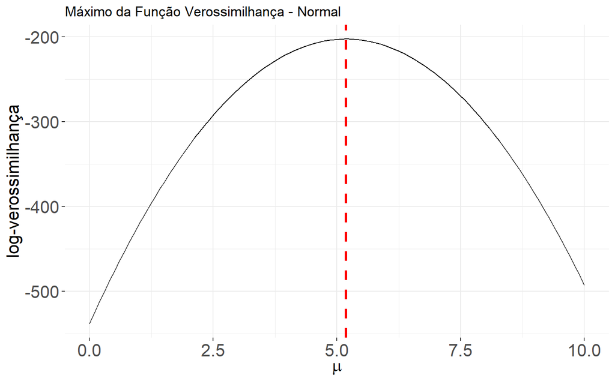

```r
# Dados simulados da normal
set.seed(123)
data = rnorm(100, mean = 5, sd = 2)

# Função de verossimilhança da normal
log_likelihood_normal = function(mu, data) {
  n = length(data)
  sigma = 2  # variância fixa
  ll = -n/2 * log(2 * pi * sigma^2) - sum((data - mu)^2) / (2 * sigma^2)
  return(ll)
}

# Maximização da verossimilhança
result_normal = optimise(function(mu) log_likelihood_normal(mu, data),
                          interval = c(0, 10), maximum = TRUE)

# Gráfico da função de verossimilhança
mu_values = seq(0, 10, length.out = 100)
ll_values = sapply(mu_values, log_likelihood_normal, data = data)
df_normal = data.frame(mu = mu_values, log_likelihood = ll_values)

ggplot(df_normal, aes(x = mu, y = log_likelihood)) +
  geom_line() +
  geom_vline(xintercept = result_normal$maximum,
             col = "red", linetype = "dashed", linewidth = 1.1) +
  labs(title = "Máximo da Função Verossimilhança - Normal",
       x = expression(mu), y = "log-verossimilhança") +
  theme_bw() +
  theme(axis.text.x = element_text(size = 16),
        axis.title.x = element_text(size = 16),
        axis.text.y = element_text(size = 16),
        axis.title.y = element_text(size = 16),
        panel.border = element_blank())
```

##### $\textrm{Beta}(\alpha,\beta)$

Suponha que temos uma amostra de uma distribuição Beta e queremos encontrar o EMV para o parâmetro $\alpha$ (fixando $\beta = 2$).

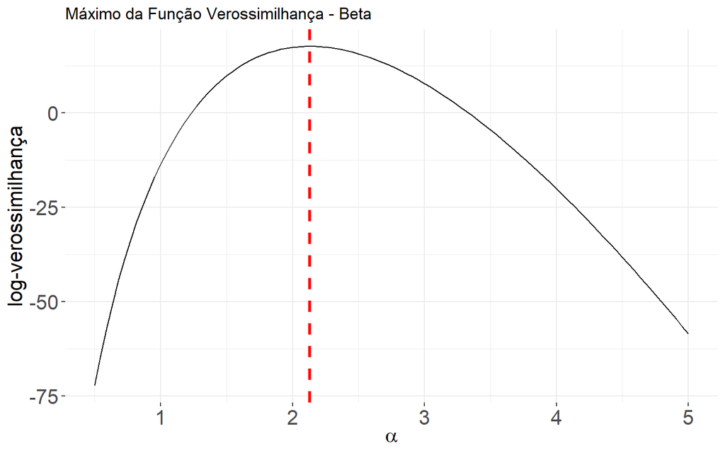

```r
# Dados simulados da Beta
set.seed(123)
data = rbeta(100, shape1 = 2, shape2 = 2)

# Função de verossimilhança da Beta
log_likelihood_beta = function(alpha, data) {
  beta = 2  # fixo
  ll = sum(dbeta(data, shape1 = alpha, shape2 = beta, log = TRUE))
  return(ll)
}

# Maximização da verossimilhança
result_beta = optimise(function(alpha) log_likelihood_beta(alpha, data),
                        interval = c(0.5, 5), maximum = TRUE)

# Gráfico da função de verossimilhança
alpha_values = seq(0.5, 5, length.out = 100)
ll_values_beta = sapply(alpha_values, log_likelihood_beta, data = data)
df_beta = data.frame(alpha = alpha_values, log_likelihood = ll_values_beta)

ggplot(df_beta, aes(x = alpha, y = log_likelihood)) +
  geom_line() +
  geom_vline(xintercept = result_beta$maximum, col = "red",
             linetype = "dashed", linewidth = 1.1) +
  labs(title = "Máximo da Função Verossimilhança - Beta",
       x = expression(alpha), y = "log-verossimilhança") +
  theme_bw() +
  theme(axis.text.x = element_text(size = 16),
        axis.title.x = element_text(size = 16),
        axis.text.y = element_text(size = 16),
        axis.title.y = element_text(size = 16),
        panel.border = element_blank())
```

##### $\textrm{Poisson}(\lambda)$

Para o modelo Poisson, queremos encontrar o EMV para o parâmetro $\lambda$.

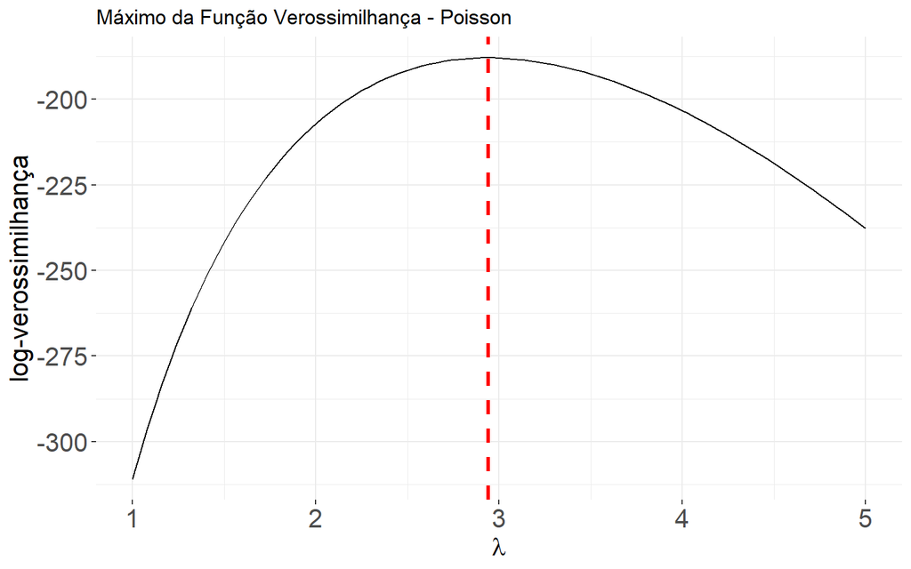

```r
# Dados simulados da Poisson
set.seed(123)
data = rpois(100, lambda = 3)

# Função de verossimilhança da Poisson
log_likelihood_poisson = function(lambda, data) {
  ll = sum(dpois(data, lambda = lambda, log = TRUE))
  return(ll)
}

# Maximização da verossimilhança
result_poisson = optimise(function(lambda) log_likelihood_poisson(lambda, data),
                           interval = c(1, 5), maximum = TRUE)

# Gráfico da função de verossimilhança
lambda_values = seq(1, 5, length.out = 100)
ll_values_poisson = sapply(lambda_values, log_likelihood_poisson, data = data)
df_poisson = data.frame(lambda = lambda_values, log_likelihood = ll_values_poisson)

ggplot(df_poisson, aes(x = lambda, y = log_likelihood)) +
  geom_line() +
  geom_vline(xintercept = result_poisson$maximum, col = "red",
             linetype = "dashed", linewidth = 1.1) +
  labs(title = "Máximo da Função Verossimilhança - Poisson",
       x = expression(lambda), y = "log-verossimilhança") +
  theme_bw() +
  theme(axis.text.x = element_text(size = 16),
        axis.title.x = element_text(size = 16),
        axis.text.y = element_text(size = 16),
        axis.title.y = element_text(size = 16),
        panel.border = element_blank())
```

##### $\textrm{Binomial}(n,p)$

Suponha que temos uma amostra de uma distribuição Binomial e queremos encontrar o EMV para a probabilidade de sucesso $p$ (com $n = 10$).

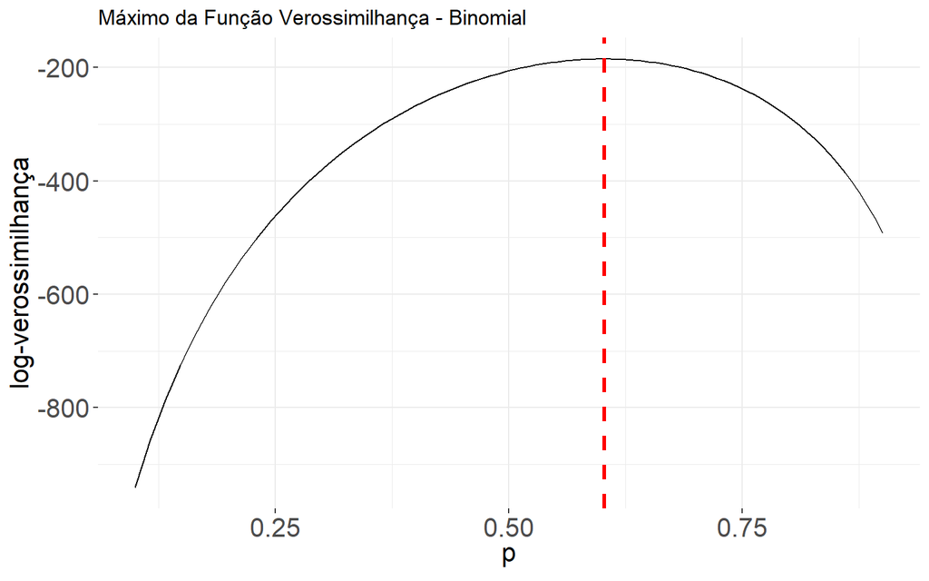

```r
# Dados simulados da Binomial
set.seed(123)
data = rbinom(100, size = 10, prob = 0.6)

# Função de verossimilhança da Binomial
log_likelihood_binomial = function(p, data) {
  n = 10  # número de tentativas fixo
  ll = sum(dbinom(data, size = n, prob = p, log = TRUE))
  return(ll)
}

# Maximização da verossimilhança
result_binomial = optimise(function(p) log_likelihood_binomial(p, data),
                           interval = c(0.1, 0.9), maximum = TRUE)

# Gráfico da função de verossimilhança
p_values = seq(0.1, 0.9, length.out = 100)
ll_values_binomial = sapply(p_values, log_likelihood_binomial, data = data)
df_binomial = data.frame(p = p_values, log_likelihood = ll_values_binomial)

ggplot(df_binomial, aes(x = p, y = log_likelihood)) +
  geom_line() +
  geom_vline(xintercept = result_binomial$maximum, col = "red",
             linetype = "dashed", linewidth = 1.1) +
  labs(title = "Máximo da Função Verossimilhança - Binomial",
       x = expression(p), y = "log-verossimilhança") +
  theme_bw() +
  theme(axis.text.x = element_text(size = 16),
        axis.title.x = element_text(size = 16),
        axis.text.y = element_text(size = 16),
        axis.title.y = element_text(size = 16),
        panel.border = element_blank())
```

#### Estimadores de Máxima Verossimilhança

##### Estimador para o Modelo Normal

Dada uma amostra $x = (x_1, x_2, \dots, x_n)$ de uma distribuição normal $N(\mu, \sigma^2)$, a função de log-verossimilhança é:

$$\ln L(\mu; x) = -\frac{n}{2} \ln(2\pi\sigma^2) - \frac{1}{2\sigma^2}
\sum_{i=1}^{n} (x_i - \mu)^2$$

Derivando em relação a $\mu$:

$$\frac{\partial}{\partial \mu} \ln L(\mu; x) = \frac{1}{\sigma^2}
\sum_{i=1}^{n} (x_i - \mu) = 0$$

O estimador de máxima verossimilhança de $\mu$ é:

$$\hat{\mu} = \frac{1}{n} \sum_{i=1}^{n} x_i$$

A segunda derivada confirma que é um ponto de máximo:

$$\frac{\partial^2}{\partial \mu^2} \ln L(\mu; x) = -\frac{n}{\sigma^2}
< 0$$

##### Estimador para o Modelo Poisson

Para a distribuição Poisson com parâmetro $\lambda$, a função de log-verossimilhança é:

$$\ln L(\lambda; x) = \sum_{i=1}^{n} \left( x_i \ln(\lambda) - \lambda -
\ln(x_i!) \right)$$

Derivando em relação a $\lambda$:

$$\frac{\partial}{\partial \lambda} \ln L(\lambda; x) = \frac{1}{\lambda}
\sum_{i=1}^{n} x_i - n = 0$$

O estimador de máxima verossimilhança para $\lambda$ é:

$$\hat{\lambda} = \frac{1}{n} \sum_{i=1}^{n} x_i$$

A segunda derivada confirma que é um ponto de máximo:

$$\frac{\partial^2}{\partial \lambda^2} \ln L(\lambda; x) =
-\frac{n}{\lambda^2} < 0$$

##### Estimador para o Modelo Binomial

Para a distribuição Binomial com parâmetro $p$ e $n$ fixo, a função de log-verossimilhança é:

$$\ln L(p; x) = \sum_{i=1}^{n} \left( x_i \ln(p) + (n - x_i) \ln(1 - p)
\right)$$

Derivando em relação a $p$:

$$\frac{\partial}{\partial p} \ln L(p; x) = \frac{1}{p} \sum_{i=1}^{n} x_i
- \frac{1}{1 - p} \sum_{i=1}^{n} (n - x_i) = 0$$

A segunda derivada confirma que é um ponto de máximo:

$$\frac{\partial^2}{\partial p^2} \ln L(p; x) = -\frac{\sum x_i}{p^2} -
\frac{\sum (n - x_i)}{(1 - p)^2} < 0$$

##### Estimador para o Modelo Beta

A função de log-verossimilhança para a distribuição Beta é complexa, então utilizamos métodos numéricos para encontrar o estimador de máxima verossimilhança. A fórmula geral para a log-verossimilhança é:

$$\ln L(\alpha, \beta; x) = n \ln \Gamma(\alpha + \beta) - n \ln
\Gamma(\alpha) - n \ln \Gamma(\beta) + (\alpha - 1) \sum_{i=1}^{n}
\ln(x_i) + (\beta - 1) \sum_{i=1}^{n} \ln(1 - x_i)$$

Neste caso, precisamos continuar recorrendo à função `optimise()` para maximizar essa função numericamente.

#### Gráficos dos Estimadores de Máxima Verossimilhança

Agora vamos gerar os gráficos para os quatro modelos, adicionando os valores dos estimadores nos gráficos. Eles serão dispostos em um grid 2x2.

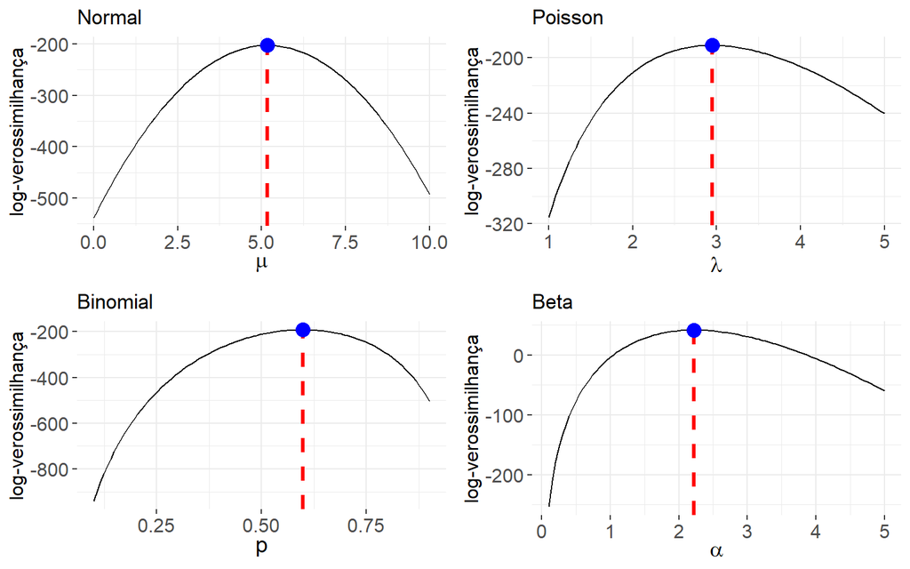

```r
# Gerando os dados
set.seed(123)

# Normal
data_normal = rnorm(100, mean = 5, sd = 2)
mu_hat = mean(data_normal)
mu_values = seq(0, 10, length.out = 100)
ll_normal = sapply(mu_values, function(mu) sum(dnorm(data_normal, mean = mu, sd = 2, log = TRUE)))
df_normal = data.frame(mu = mu_values, log_likelihood = ll_normal)

p1 = ggplot(df_normal, aes(x = mu, y = log_likelihood)) +
  geom_line() +
  geom_vline(xintercept = mu_hat, col = "red",
             linetype = "dashed", linewidth = 1.1) +
  geom_point(aes(x = mu_hat, y = max(ll_normal)),
             col = "blue", size = 4) +
  labs(title = "Normal", x = expression(mu), y = "log-verossimilhança") +
  theme_bw() +
  theme(axis.text.x = element_text(size = 12),
        axis.title.x = element_text(size = 14),
        axis.text.y = element_text(size = 12),
        axis.title.y = element_text(size = 12),
        panel.border = element_blank())

# Poisson
data_poisson = rpois(100, lambda = 3)
lambda_hat = mean(data_poisson)
lambda_values = seq(1, 5, length.out = 100)
ll_poisson = sapply(lambda_values, function(lambda) sum(dpois(data_poisson, lambda, log = TRUE)))
df_poisson = data.frame(lambda = lambda_values, log_likelihood = ll_poisson)

p2 = ggplot(df_poisson, aes(x = lambda, y = log_likelihood)) +
  geom_line() +
  geom_vline(xintercept = lambda_hat, col = "red",
             linetype = "dashed", linewidth = 1.1) +
  geom_point(aes(x = lambda_hat, y = max(ll_poisson)),
             col = "blue", size = 4) +
  labs(title = "Poisson", x = expression(lambda), y = "log-verossimilhança") +
  theme_bw() +
  theme(axis.text.x = element_text(size = 12),
        axis.title.x = element_text(size = 14),
        axis.text.y = element_text(size = 12),
        axis.title.y = element_text(size = 12),
        panel.border = element_blank())

# Binomial
data_binomial = rbinom(100, size = 10, prob = 0.6)
p_hat = mean(data_binomial / 10)
p_values = seq(0.1, 0.9, length.out = 100)
ll_binomial = sapply(p_values, function(p) sum(dbinom(data_binomial, size = 10, prob = p, log = TRUE)))
df_binomial = data.frame(p = p_values, log_likelihood = ll_binomial)

p3 = ggplot(df_binomial, aes(x = p, y = log_likelihood)) +
  geom_line() +
  geom_vline(xintercept = p_hat, col = "red",
             linetype = "dashed", linewidth = 1.1) +
  geom_point(aes(x = p_hat, y = max(ll_binomial)),
             col = "blue", size = 4) +
  labs(title = "Binomial", x = expression(p), y = "log-verossimilhança") +
  theme_bw() +
  theme(axis.text.x = element_text(size = 12),
        axis.title.x = element_text(size = 14),
        axis.text.y = element_text(size = 12),
        axis.title.y = element_text(size = 12),
        panel.border = element_blank())

# Beta (simulação para o gráfico)
data_beta = rbeta(100, shape1 = 2, shape2 = 5)
alpha_hat = optimise(function(alpha) sum(dbeta(data_beta, shape1 = alpha, shape2 = 5, log = TRUE)),
                      interval = c(0.1, 10), maximum = TRUE)$maximum
alpha_values = seq(0.1, 5, length.out = 100)
ll_beta = sapply(alpha_values, function(alpha) sum(dbeta(data_beta, shape1 = alpha, shape2 = 5, log = TRUE)))
df_beta = data.frame(alpha = alpha_values, log_likelihood = ll_beta)

p4 = ggplot(df_beta, aes(x = alpha, y = log_likelihood)) +
  geom_line() +
  geom_vline(xintercept = alpha_hat, col = "red",
             linetype = "dashed", linewidth = 1.1) +
  geom_point(aes(x = alpha_hat, y = max(ll_beta)),
             col = "blue", size = 4) +
  labs(title = "Beta", x = expression(alpha), y = "log-verossimilhança") +
  theme_bw() +
  theme(axis.text.x = element_text(size = 12),
        axis.title.x = element_text(size = 14),
        axis.text.y = element_text(size = 12),
        axis.title.y = element_text(size = 12),
        panel.border = element_blank())

# Criando o grid com 2x2
grid.arrange(p1, p2, p3, p4, ncol = 2)
```

> **Desafio:** Encontre a estimativa de máxima verossimilhança do parâmetro $\lambda$ da distribuição exponencial, maximizando a função de log-verossimilhança, se foi observada uma amostra com os seguintes valores: $x = c(2.5, 3.6, 7.1, 2.1, 3.0, 4.8, 9.5, 2.3, 3.3, 1.9)$. Faça tanto utilizando a função `optimise` quanto encontrando o estimador de $\lambda$ pelo método da máxima verossimilhança.